# Miscellaneous observations about BayesR II

First we generate the testing data set using now two mixtures of effects

```r
M=200 #non zero marker effects
N=2000 #observations
MT=5000 #number of markers
B=matrix(rep(0,MT,ncol=1))
indexes <- sample(1:MT,M)
B[indexes[1:(M/4)],1]=rnorm(M/4,sd=sqrt(0.3/(M/4))) #marker effects, M marquers explain approx 50% of the variance
B[indexes[(3*M/4+1):M]]=rnorm(3*M/4,sd=sqrt(0.2/(3*M/4)))
```

```
number of items to replace is not a multiple of replacement length
```

```r
#B[sample(1:MT,MT-M),1]=0 #we set MT-M marker effects to zero
#B=-abs(B)
X <- matrix(rnorm(MT*N), N, MT); var(X[,1])
```

```
[1] 1.01098
```

```r
G <- scale(X)%*%B;
var(G)
```

```
          [,1]
[1,] 0.4428593
```

```r
Y=G
Covariates <- matrix(rnorm(N*2,sd = 1),ncol=2)
C <- c(1/(2*sqrt(5)),-1/(2*sqrt(5)))
Y = Y+ scale(Covariates) %*% C
var(scale(Covariates) %*% C)
```

```
          [,1]
[1,] 0.1039406
```

```r
e = rnorm(N,sd=sqrt(0.4))
Y = Y + e
var(e)
```

```
[1] 0.3963056
```

```r
var(Y)
```

```
          [,1]
[1,] 0.9846393
```

```r
#Y=scale(Y)
X=scale(X)
iter=20000
burnin =10000
thin=10
```

## Alternative parametrizations

Here we source the BayesR that uses $\sigma_G$ and the alternative parametrization using $\sigma_\beta$, the difference comes when sampling from the scaled inverse chi squared distribution.

Now we source BayesR

```r
Rcpp::sourceCpp('../src/BayesRv2.cpp')
```

```
> # M=200 #non zero marker effects
> # N=2000 #observations
> # MT=5000 #number of markers
> # B=matrix(rnorm(MT,sd=sqrt(0.5/M)),ncol=1) #marker effec .... [TRUNCATED]
```

And create a small function to plot relevant output

```r
library(readr)
plot_output<-function(sampleFile){
  tmp <- as.matrix(data.table::fread(sampleFile))
  #names(tmp)
  #plot(tmp$sigmaG); mean(tmp$sigmaG)
  plot(B,colMeans(tmp[,grep("beta",colnames(tmp))]), xlab = "true beta",ylab = "mean beta inferred",main = "true vs mean inferred betas" )
  lines(B,B)
  abline(h=0)
  par(mfrow=c(3,2),pch='.')

  comps<-tmp[,grep("comp",colnames(tmp))]
  invComps<-apply(comps,MARGIN=1,FUN = function(x){sum(ifelse(x==0,0,1/x))})
  tmp<- data.table::fread(sampleFile)

  plot(tmp$mu, xlab="iteration" , ylab ="mu trace plot")
  plot(tmp$sigmaE/(tmp$sigmaE+tmp$sigmaF+tmp$sigmaG), xlab="iteration",ylab ="sigmaE / total_variance")
  abline(h=var(e)/(var(e)+var(G)+var(C)))
  plot(tmp$sigmaG/(tmp$sigmaE+tmp$sigmaF+tmp$sigmaG),xlab = "iteration", ylab = "sigmaG / total_variance")
  abline(h=var(G)/(var(e)+var(G)+var(C)))
  plot(tmp$sigmaF/(tmp$sigmaE+tmp$sigmaF+tmp$sigmaG), xlab = "iteration", ylab = "sigmaF / total_variance")
  abline(h=var(C)/(var(e)+var(G)+var(C)))
  plot(as.matrix(tmp)[,"gamma[1]"], xlab ="iteration" , ylab= "gamma[1]")
  abline(h=C[1])
  plot(as.matrix(tmp)[,"gamma[2]"],xlab = "itration", ylab = "gamma[2]")
  abline(h=C[2])

  par(mfrow=c(3,2),pch='.')
  plot(tmp$m0,xlab="iteration",main="traceplot of markers in model")
  abline(h=200)
  hist(tmp$m0,breaks=100,main = "histogram of markers in model")
  abline(v=200)
  plot(invComps, xlab= "iteration", main= "sum of inverse of components variances")
  hist(invComps,main="histogram of sum of inverse of components variances")
  plot(tmp$m0,invComps,xlab = "markers in model", ylab="sum of inverse comp. variances")
}
```

And run the normal BayesR

```r
P=0.5 #prior probability of a marker being excluded from the model
sigma0=0.01# prior  variance of a zero mean gaussian prior over the mean mu NOT IMPLEMENTED
v0E=0.01 # degrees of freedom over the inv scaled chi square prior over residuals variance
s02E=0.01 #scale of the inv scaled chi square prior over residuals variance
v0G=0.01 #degrees of freedom of the inv bla bla prior over snp effects
s02G=0.01 # scale for the same
BayesRSamplerV2("./test.csv",2, iter, burnin,thin,X, scale(Y),sigma0,v0E,s02E,v0G,s02G,c(0.1,0.01),scale(Covariates))
```

```
iteration: 2000
iteration: 4000
iteration: 6000
iteration: 8000
iteration: 10000
iteration: 12000
iteration: 14000
iteration: 16000
iteration: 18000
duration: 263s
```

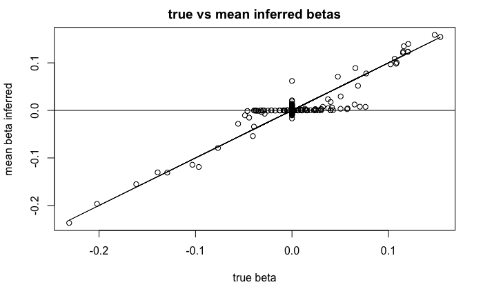

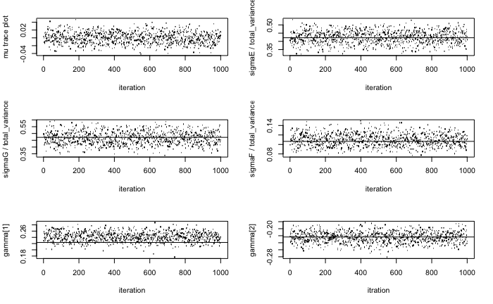

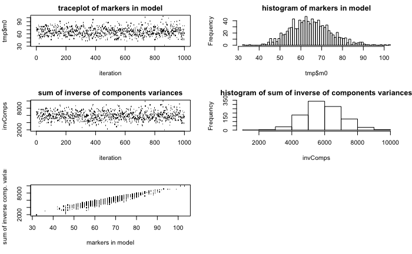

```r
plot_output('./test.csv')
```

```r
tmp<-as.matrix(data.table::fread("test.csv"))
```

We now see what happens if we add another component

```r
P=0.5 #prior probability of a marker being excluded from the model
sigma0=0.01# prior  variance of a zero mean gaussian prior over the mean mu NOT IMPLEMENTED
v0E=0.01 # degrees of freedom over the inv scaled chi square prior over residuals variance
s02E=0.01 #scale of the inv scaled chi square prior over residuals variance
v0G=0.01 #degrees of freedom of the inv bla bla prior over snp effects
s02G=0.01 # scale for the same
BayesRSamplerV2("./test2.csv",2, iter, burnin,thin,X, scale(Y),sigma0,v0E,s02E,v0G,s02G,c(0.1,0.01,0.001),scale(Covariates))
```

```
iteration: 2000
iteration: 4000
iteration: 6000
iteration: 8000
iteration: 10000
iteration: 12000
iteration: 14000
iteration: 16000
iteration: 18000
duration: 241s
```

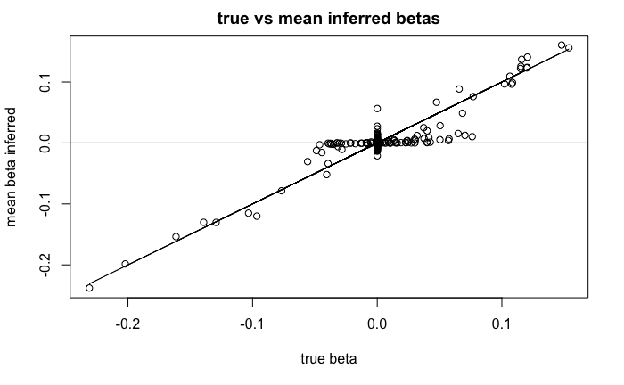

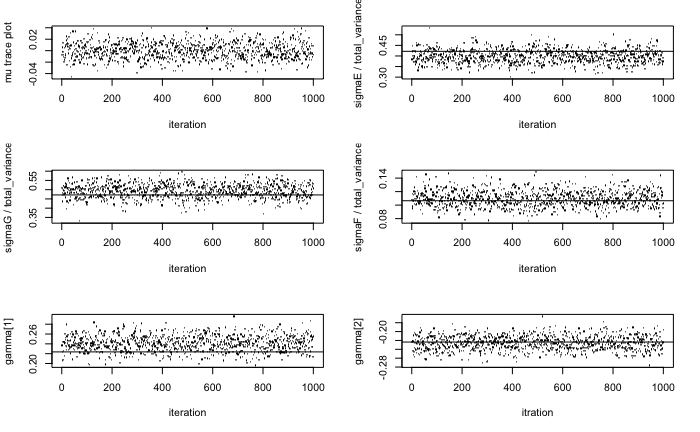

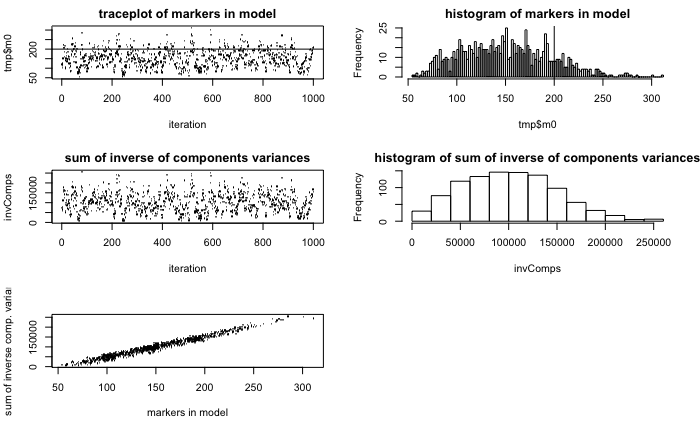

```r
plot_output("test2.csv")
```

# alternative parametrization

now we run BayesR with the alternative parametrization

```r
BayesRSamplerV2sigmaB("./test3.csv",2, iter, burnin,thin,X, scale(Y),sigma0,v0E,s02E,v0G,s02G,c(0.1),scale(Covariates))
```

```
iteration: 2000
iteration: 4000
iteration: 6000
iteration: 8000
iteration: 10000
iteration: 12000
iteration: 14000
iteration: 16000
iteration: 18000
duration: 245s
```

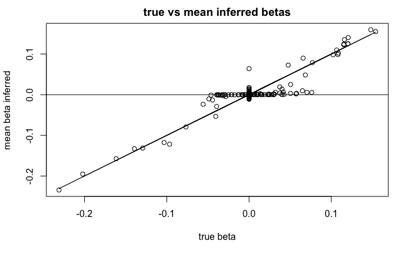

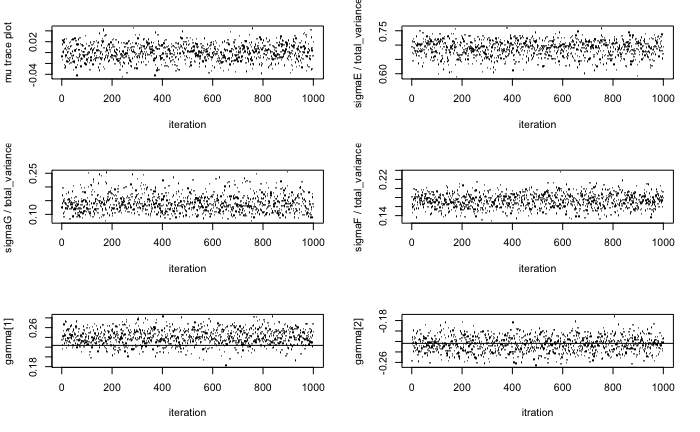

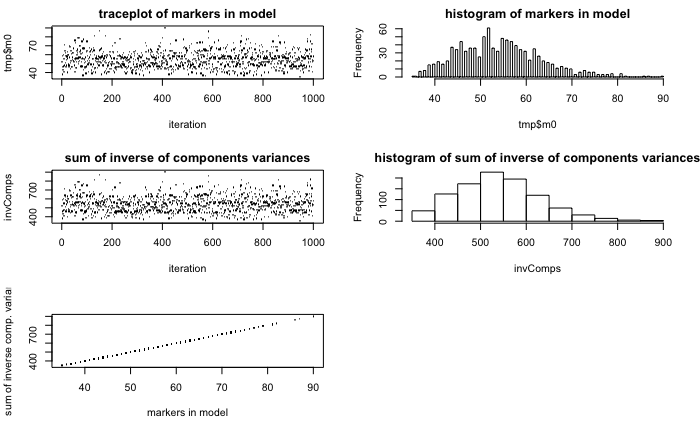

```r
plot_output("./test3.csv")
```

Given that in the $\sigma_beta$ parametrization we have $\sigma_\beta = var(\mathbf{X}\beta)$ we need to compute it like this

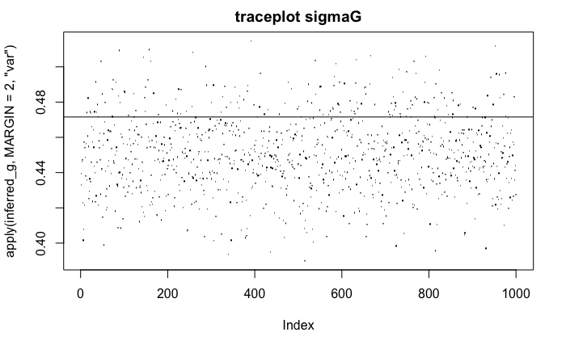

```r
tmp<- data.table::fread("test3.csv")
betas <- as.matrix(tmp)[,grep("beta",colnames(tmp))]
inferred_g <- scale(X) %*% t(betas)
par(pch=".")
plot(apply(inferred_g,MARGIN = 2,"var"),ylabel= "sigmaG", main="traceplot sigmaG")
abline(h=var(G)/(var(e)+var(G)+var(C)))
```

If we add extra components we get less sparse solutions

```r
BayesRSamplerV2sigmaB("./test4.csv",2, iter, burnin,thin,X, scale(Y),sigma0,v0E,s02E,v0G,s02G,c(0.1,0.01,0.001),scale(Covariates))
```

```
iteration: 2000
iteration: 4000
iteration: 6000
iteration: 8000
iteration: 10000
iteration: 12000
iteration: 14000
iteration: 16000
iteration: 18000
duration: 249s
```

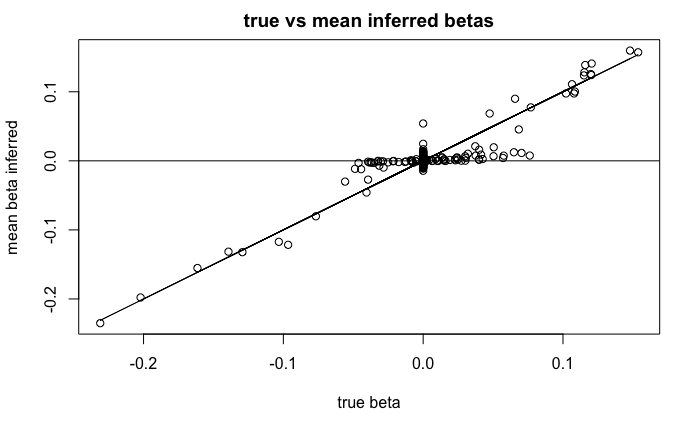

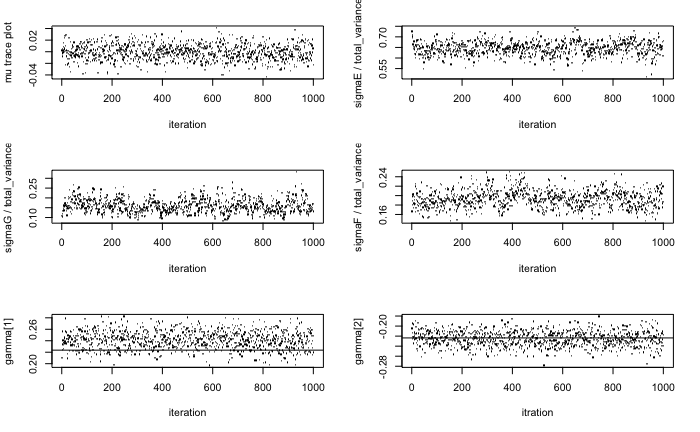

```r
plot_output("./test4.csv")
```

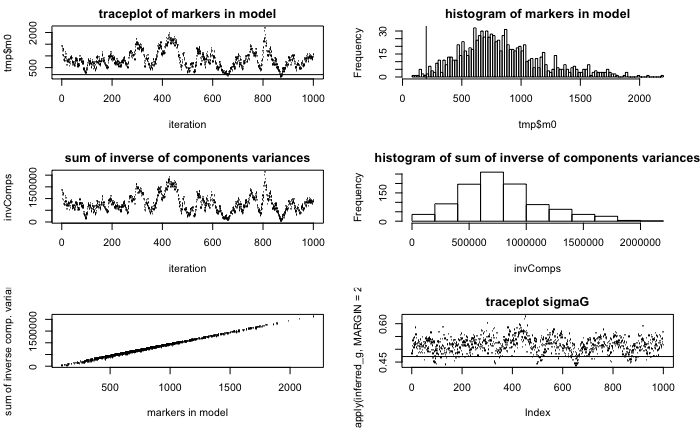

```r
tmp<- data.table::fread("test4.csv")
betas <- as.matrix(tmp)[,grep("beta",colnames(tmp))]
inferred_g <- scale(X) %*% t(betas)
plot(apply(inferred_g,MARGIN = 2,"var"),ylabel= "sigmaG", main="traceplot sigmaG")
abline(h=var(G)/(var(e)+var(G)+var(C)))
```

now with only two mixtures

```r
BayesRSamplerV2sigmaB("./test5.csv",2, iter, burnin,thin,X, scale(Y),sigma0,v0E,s02E,v0G,s02G,c(0.1,0.01),scale(Covariates))
```

```
iteration: 2000
iteration: 4000
iteration: 6000
iteration: 8000
iteration: 10000
iteration: 12000
iteration: 14000
iteration: 16000
iteration: 18000
duration: 276s
```

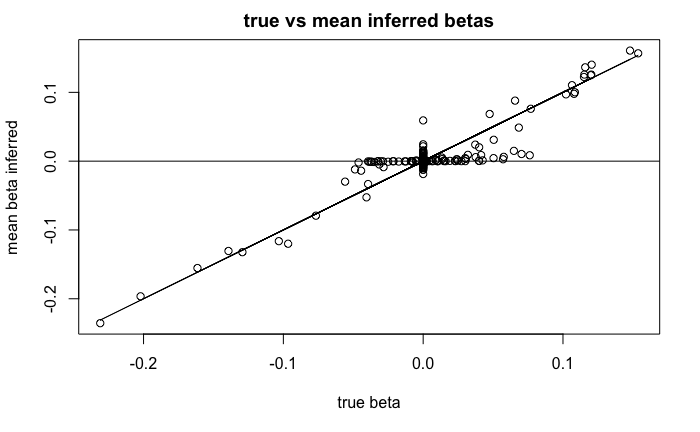

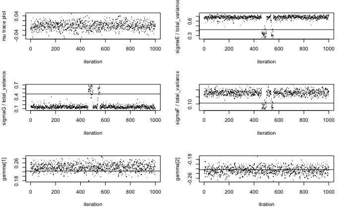

```r
plot_output("./test5.csv")
```

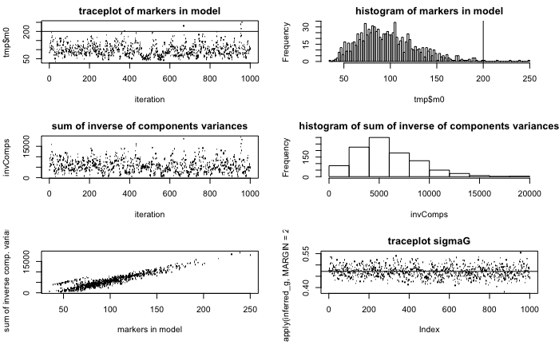

```r
tmp<- data.table::fread("test5.csv")
betas <- as.matrix(tmp)[,grep("beta",colnames(tmp))]
inferred_g <- scale(X) %*% t(betas)
plot(apply(inferred_g,MARGIN = 2,"var"),ylabel= "sigmaG", main="traceplot sigmaG")
abline(h=var(G)/(var(e)+var(G)+var(C)))
```

We see the effective sample size

| moddel | Neff |
| --- | --- |
| BayesR2mix | 1000.00000 |
| BayesR3mix | 269.84062 |
| SigmaB1mix | 1000.00000 |
| sigmaB2mix | 362.91030 |
| sigmaB3mix | 59.31938 |